# Generating a gallery of clothes while using interactive IPython notebook tools

Wed, 02 Jul 2014

[Clothes](http://flothesof.github.io/tag/clothes.html) [Real life](http://flothesof.github.io/tag/real-life.html)

This post is dedicated to a small clothing experiment. With the help of Google, I've downloaded images of pants and t-shirts (or shirts) from the internet. Using Python and matplotlib, I will generate and display random pairings from these images.

First, let's load the data I've saved to my hard drive:

- we read a bunch of filenames
- and we create a dictionary containing the paths to the different clothing elements

```python
import os
parent_dir = 'files/clothes/'
clothes = os.listdir(parent_dir)
```

We create a helper function that separates the prefix of the file from the rest of the name:

```python
clothe_type = lambda s: s.split('_')[0]
```

```python
clothe_type("tshirt_1.jpg")
```

```
'tshirt'
```

And now we create a dictionary from the filenames:

```python
from collections import defaultdict
clothes_dict = defaultdict(list)
for item in clothes:
    clothes_dict[clothe_type(item)].append(os.path.join(parent_dir, item))
```

```python
clothes_dict.keys()
```

```
['tshirt', 'pants']
```

As we now have a dictionary listing our images, we're going to define a function able to visualize a top and a bottom element (basically a shirt and pants).

To display that, we plot the top and the bottom on the same axes, but with different extents. Let's demo this below.

```python
%matplotlib inline
from pylab import *
```

```
(0, 1)
```

[figure not shown]

```python
imshow(imread(clothes_dict['tshirt'][3]), extent=(0.25, 0.75, 0.5, 1))
imshow(imread(clothes_dict['pants'][6]), extent=(0.1, 0.9, 0, 0.5))
xlim(0, 1)
ylim(0, 1)
```

```python
def plot_outfit(top, bottom):
    im_top = imread(clothes_dict['tshirt'][top])
    im_bottom = imread(clothes_dict['pants'][bottom])
    imshow(im_bottom, extent=(0.1, 0.9, 0, 0.5))
    imshow(im_top, extent=(0.25, 0.75, 0.5, 1))
    xlim(0, 1)
    ylim(0, 1)
    axis('off')
```

This function can be immediately tested:

[figure not shown]

```python
plot_outfit(1, 2)
```

Now, let's move on to the fun part: we can use randomness and a click button from the IPython interactive widget tools to generate arbirtary outfits.

```python
from IPython.html.widgets import interact
from IPython.html import widgets
from IPython.display import display, clear_output
```

```python
button = widgets.ButtonWidget(description="Change clothes!")
display(button)

def on_button_clicked(b):
    clear_output()
    top = randint(0, len(clothes_dict['tshirt']))
    bottom = randint(0, len(clothes_dict['pants']))
    plot_outfit(top, bottom)

button.on_click(on_button_clicked)
```

Unfortunately, the interactive part is not displayed in the IPython Notebook static rendering. Therefore I made a screenshot that is shown below showing the interactive button created with the code in the above cell:

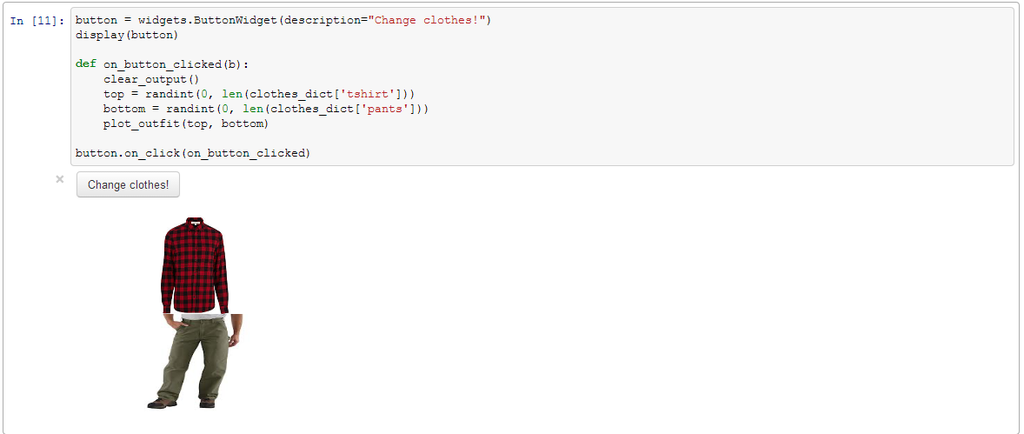

```python
from IPython.display import Image
Image(filename='files/clothes_interactive.PNG')
```

It's quite fun clicking on that button! To conclude this post, let's apply the previously defined function `plot outfit` to a grid to generate a lot of random outfits!

[figure not shown]

```python
figure(figsize=(10, 10))
n, m = 8, 8
for i in range(n * m):
    subplot(n, m, i+1)
    top = randint(0, len(clothes_dict['tshirt']))
    bottom = randint(0, len(clothes_dict['pants']))
    plot_outfit(top, bottom)
```

This article has been tagged with the following terms:

[Clothes](http://flothesof.github.io/tag/clothes.html) [Real life](http://flothesof.github.io/tag/real-life.html)

[figure not shown]